# Homework 2&3

Filiz Günal - IE360 - SPRING 2020

07 05 2020

## INTRODUCTION

Collected data is the fundamental element in prediction and has been widely used in different sectors for over 10 years. It is important to understand the behaviour of the data and to determine if there is any seasonality or trend, before making any prediction. Afterwards, most appropriate model should be used in order to make a successful prediction.

In this homework, hourly electric consumption data, which is token from EPIAS, is used to make 24 hour ahead forecasts with AR and MA models. First, the data aggregated to different frequencies and its behaviour is observed. Then, the pattern of the data is determined. The data is decomposed in order to deseasonilize and to detrend. After these, AR and MA models are used to make 24 hour ahead forecasts.

## APPROACH

The required libraries are determined. The data is rearranged in order to make further steps easier to perform with the given code below.

```r
library(data.table)
library(zoo)
library(xts)
library(forecast)
library(stats)
elec <- fread("/Users/Asus/Downloads/RealTimeConsumption.csv", skip=0) #import data
date_elec <- as.Date.character(elec$Date, format="%d.%m.%Y", tryFormats = "%Y-%m-%d")
elec$Date <- date_elec
rename_elec <- c("date", "hour", "cons")
setnames(elec, names(elec), rename_elec)
elec$cons <- as.numeric(gsub(",", "", elec$cons))
elec$cons <- elec$cons/1000
elec[,hour:=NULL]
setDF(elec)
str(elec)
```

```
## 'data.frame':    37848 obs. of  2 variables:
##  $ date: Date, format: "2016-01-01" "2016-01-01" ...
##  $ cons: num  26.3 25 23.5 22.5 22 ...
```

```r
head(elec)
```

```
##         date     cons
## 1 2016-01-01 26.27724
## 2 2016-01-01 24.99182
## 3 2016-01-01 23.53261
## 4 2016-01-01 22.46478
## 5 2016-01-01 22.00291
## 6 2016-01-01 21.95708
```

The electric consumption data is decomposed to hourly, daily, weekly, monthly, quarterly, and yearly levels. The data and associated ACF values are plotted to determine the pattern of electric consumption as shown below.

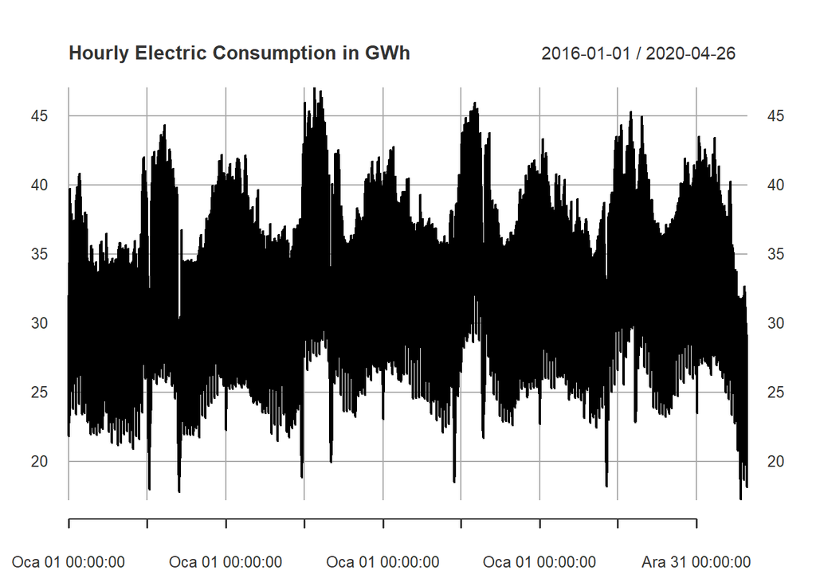

```r
#decompose the series at different levels
elec_hourly<- xts(elec$cons,  order.by = date_elec)
elec_hourly_ts <- ts(elec_hourly)
plot.xts(elec_hourly, main="Hourly Electric Consumption in GWh")
```

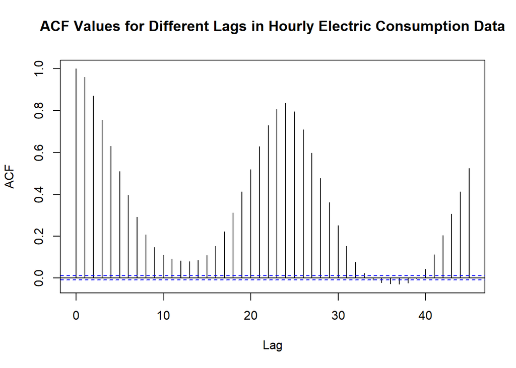

```r
acf(elec_hourly_ts, main="ACF Values for Different Lags in Hourly Electric Consumption Data")
```

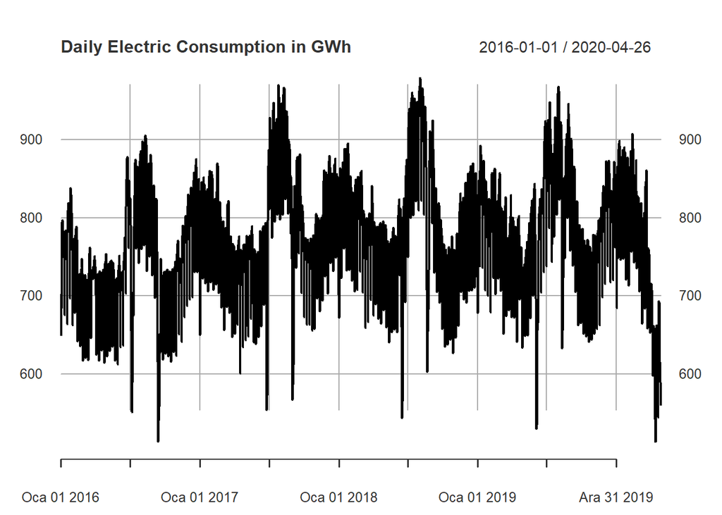

```r
elec_daily <- apply.daily(elec_hourly, FUN = "sum")
elec_daily_ts <-ts(elec_daily)
plot.xts(elec_daily, main="Daily Electric Consumption in GWh")
```

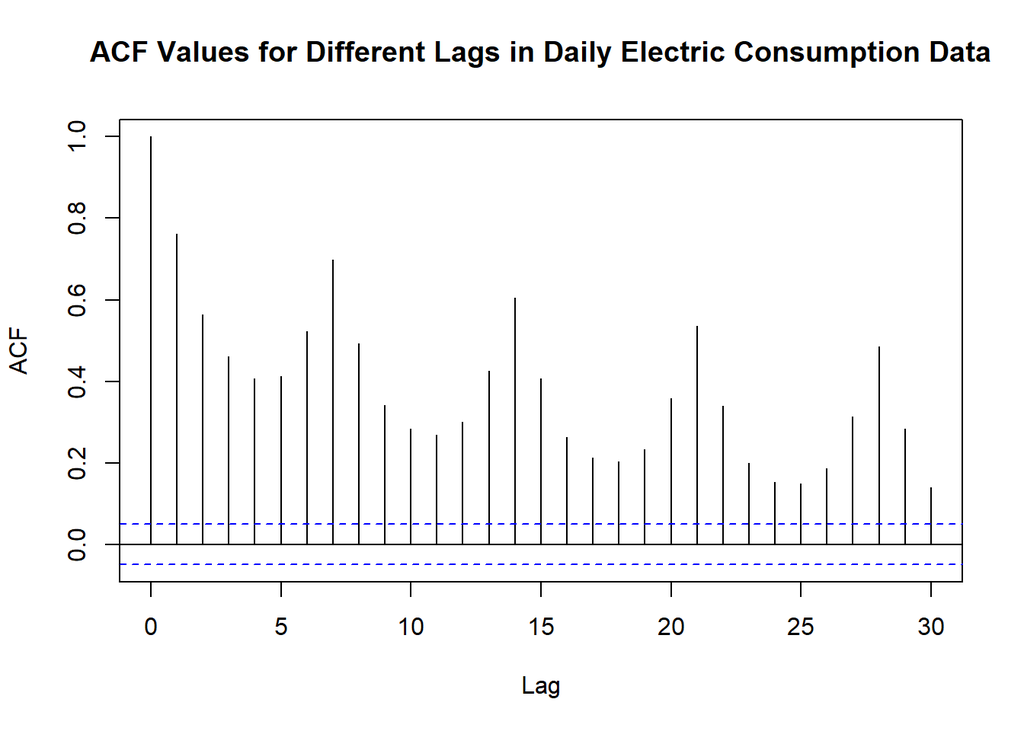

```r
acf(elec_daily_ts, lag.max = 30, main="ACF Values for Different Lags in Daily Electric Consumption Data")
```

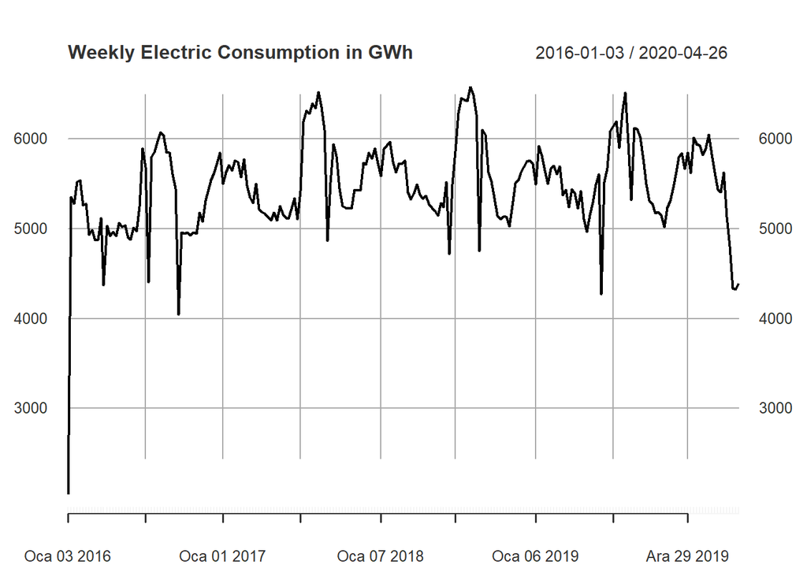

```r
elec_weekly<- apply.weekly(elec_daily, FUN = "sum")
elec_weekly_ts <- ts(elec_weekly)
plot.xts(elec_weekly,main="Weekly Electric Consumption in GWh")
```

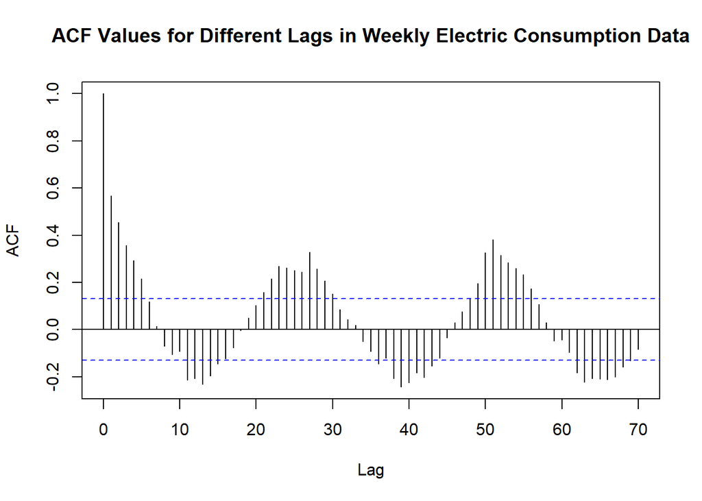

```r
acf(elec_weekly_ts, lag.max = 70, main="ACF Values for Different Lags in Weekly Electric Consumption Data")
```

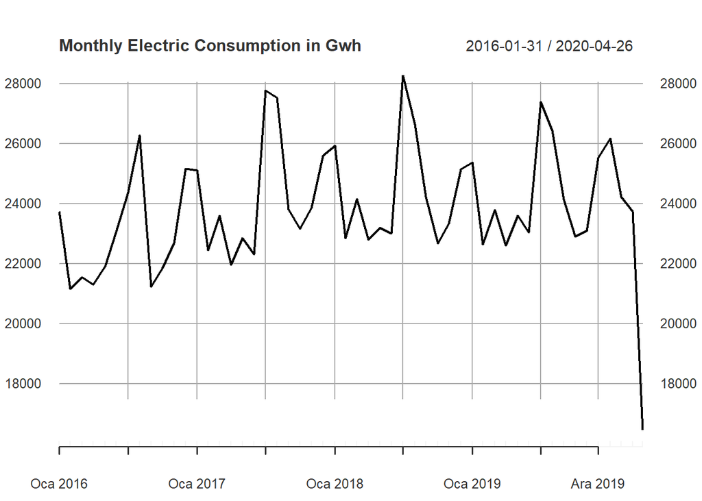

```r
elec_monthly <- apply.monthly(elec_daily, FUN="sum")
elec_monthly_ts <- ts(elec_monthly)
plot.xts(elec_monthly, main="Monthly Electric Consumption in Gwh")
```

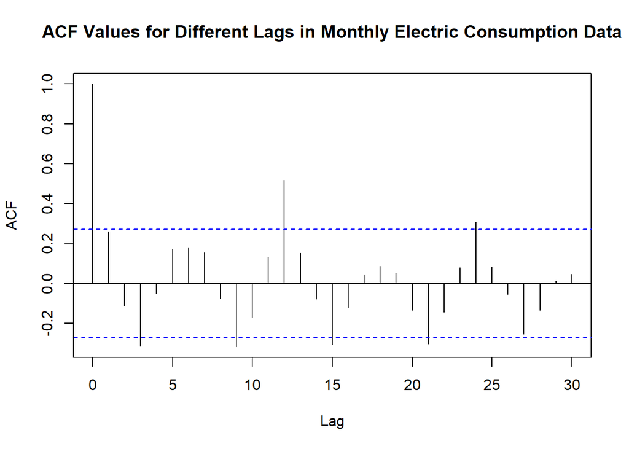

```r
acf(elec_monthly_ts, lag.max = 30, main="ACF Values for Different Lags in Monthly Electric Consumption Data")
```

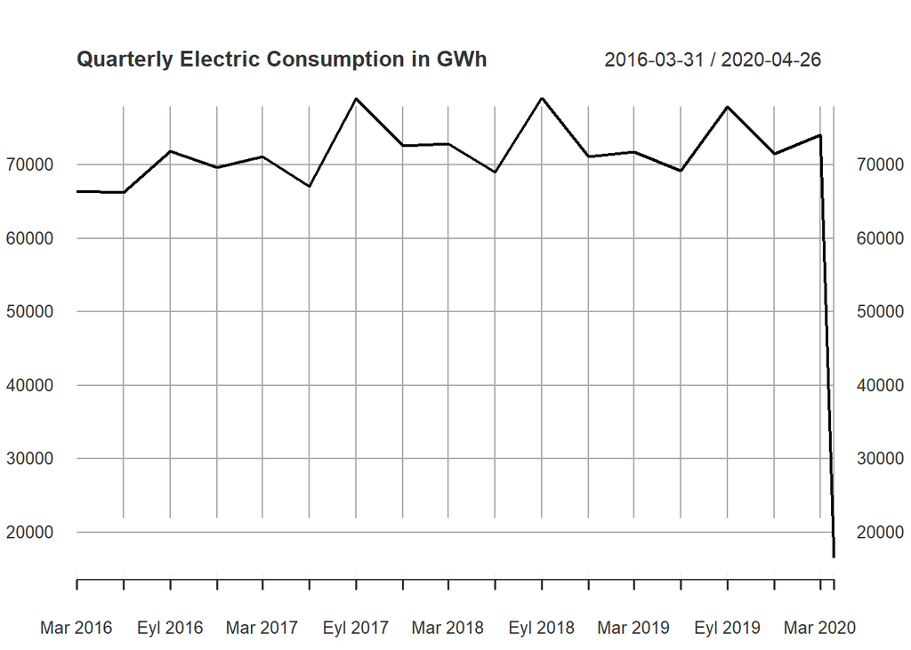

```r
elec_quarterly <- apply.quarterly(elec_daily, FUN = "sum")
elec_quarterly_ts <- ts(elec_quarterly)
plot.xts(elec_quarterly, main="Quarterly Electric Consumption in GWh")
```

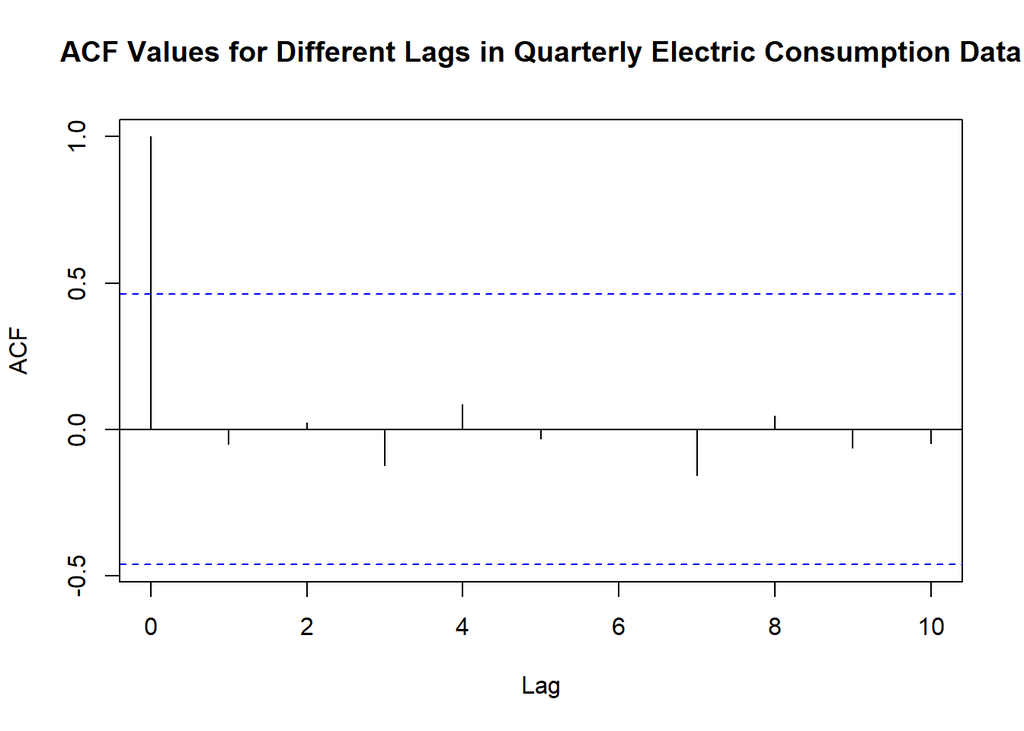

```r
acf(elec_quarterly_ts, lag.max = 10, main="ACF Values for Different Lags in Quarterly Electric Consumption Data")
```

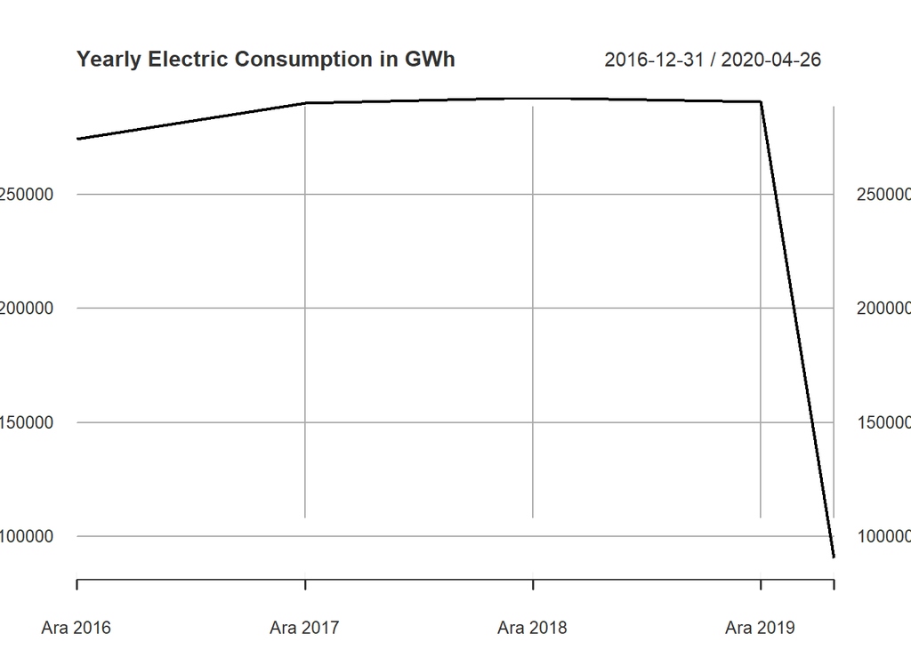

```r
elec_yearly <- apply.yearly(elec_daily, FUN = "sum")
elec_yearly_ts <- ts(elec_yearly)
plot.xts(elec_yearly, main="Yearly Electric Consumption in GWh")
```